# BANA 7050 Time series and forecasting

## Section 3

### Moving Averages

After filtering our data, we visualize the moving averages with different orders to gain further insight into our time series data. As we know moving averages average values from a window of consecutive time periods, thereby generating a series of averages. Though logically as the the order increases the curve tends to get smoother and that is what has been observed in our plot we cannot ignore the structure of data while choosing which moving average order to consider for our data. Assuming that the temperature changes increase/decrease roughly in a consistent way throughout a single year, the order 13 moving average seems to fit the data better.

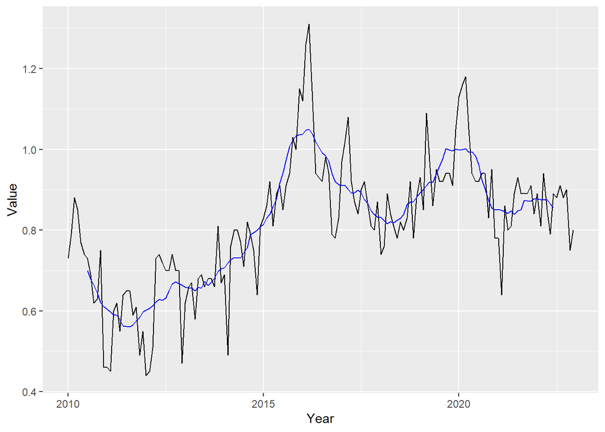

```r
library(zoo)
library(feasts)
data_monthly %>%
    filter(Year>='2010-01-01') %>%
    mutate(year_moving_average = rollmean(Value,13,na.pad=T)) %>%
    ggplot()+
    geom_line(aes(Year,Value,group=1))+
    geom_line(aes(Year,year_moving_average,group=1),color='blue')
```

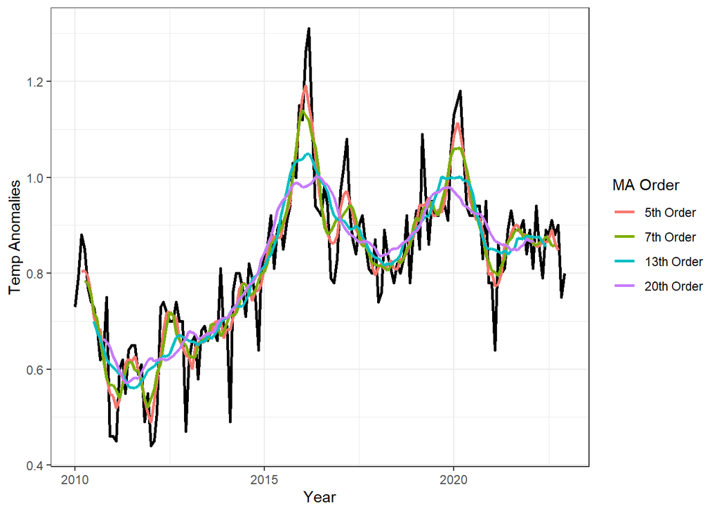

```r
library(zoo)
library(ggplot2)

 # Adding the multi order
 d1new <- data_monthly %>%
   arrange(Year) %>%
   mutate(
     value_ma_5 = rollapply(Value, 5, FUN = mean, align = "center", fill = NA),
     value_ma_7 = rollapply(Value, 7, FUN = mean, align = "center", fill = NA),
     value_ma_13 = rollapply(Value, 13, FUN = mean, align = "center", fill = NA),
     value_ma_20 = rollapply(Value, 20, FUN = mean, align = "center", fill = NA) )



 data_pivot <- d1new %>%
   pivot_longer(
     cols = value_ma_5:value_ma_20,
     values_to = "value_ma",
     names_to = "ma_order"
   ) %>%
   mutate(ma_order = factor(
     ma_order,
     levels = c(
       "value_ma_5",
       "value_ma_7",
       "value_ma_13",
       "value_ma_20"
     ),
     labels = c(
       "value_ma_5",
       "value_ma_7",
       "value_ma_13",
       "value_ma_20"
     )
   ))


 ### Comparison of different moving averages

data_pivot %>%
   mutate(ma_order = case_when(
     ma_order=='value_ma_5'~'5th Order',
     ma_order=='value_ma_7'~'7th Order',
     ma_order=='value_ma_13'~'13th Order',
     ma_order=='value_ma_20'~'20th Order')
   ) %>%
   mutate(
     ma_order = factor(
       ma_order,
       labels = c('5th Order',
                  '7th Order',
                  '13th Order',
                  '20th Order'),
       levels = c('5th Order',
                  '7th Order',
                  '13th Order',
                  '20th Order')
     )
   ) %>%
   ggplot() +
   geom_line(aes(Year, Value), size = 1, group = 1) +
   geom_line(aes(Year, value_ma, color = ma_order), size = 1, group = 1) +
   scale_color_discrete(name = 'MA Order')+
   theme_bw()+
   ylab('Temp Anomalies')
```

### Moving Averages Analysis on our data :

```r
Temp_decomp <- data_monthly %>%
mutate(
 ma_13_centre = rollapply(Value, 13, FUN = mean, align = "center", fill = NA)
 ) %>%
 mutate(resid = Value - ma_13_centre) %>%
 select(Year, Value, ma_13_centre, resid)

Temp_decomp_plot <- Temp_decomp %>%
 pivot_longer(
 Value:resid,
 names_to = "decomposition",
 values_to = "Value"
 ) %>%
 mutate(
 decomposition = case_when(
 decomposition == "Value" ~ "Temp Anomalies",
 decomposition == "ma_13_centre" ~ "Trend",
 decomposition == "resid" ~ "Remainder"
 )
 ) %>%
 mutate(
 decomposition = factor(
 decomposition,
 labels = c(
 "Temp Anomalies",
 "Trend",
 "Remainder"
 ),
 levels = c(
 "Temp Anomalies",
 "Trend",
 "Remainder"
 )
 )
 ) %>%
 ggplot() +
 geom_line(aes(Year, Value), size = 1) +
 facet_wrap(
 ~decomposition,
 nrow = 3,
 scales = "free"
 ) +
 theme_bw() +
 ylab("") +
 xlab("YEAR") +
 ggtitle(
    "Temp Anomalies = Trend + Remainder"
  )
```

[figure not shown]

```r
data_monthly %>%
  mutate(Year = yearmonth(Year)) %>%
          as_tsibble(index = Year) %>%
  model(
    Naive = NAIVE(Value)
  ) %>%
  forecast(h = 6) %>%
  autoplot(data_monthly, level = NULL,size=1) +
  geom_vline(aes(xintercept = ymd("2022-12-01")), color = "red", linetype = "dashed") +
  theme_bw()+
  ylab('Temp Anomalies')
```